# R Notebook

```r
library(tidyverse)
```

- Coerce (force) a data frame to a tibble with `as_tibble()`

| Sepal.Length | Sepal.Width | Petal.Length | Petal.Width | Species |
| --- | --- | --- | --- | --- |
| 5.1 | 3.5 | 1.4 | 0.2 | setosa |
| 4.9 | 3.0 | 1.4 | 0.2 | setosa |
| 4.7 | 3.2 | 1.3 | 0.2 | setosa |
| 4.6 | 3.1 | 1.5 | 0.2 | setosa |
| 5.0 | 3.6 | 1.4 | 0.2 | setosa |
| 5.4 | 3.9 | 1.7 | 0.4 | setosa |
| 4.6 | 3.4 | 1.4 | 0.3 | setosa |
| 5.0 | 3.4 | 1.5 | 0.2 | setosa |
| 4.4 | 2.9 | 1.4 | 0.2 | setosa |
| 4.9 | 3.1 | 1.5 | 0.1 | setosa |

[output cut: 140 more lines]

You can create a new tibble from individual vectors with `tibble()`. `tibble()` will automatically recycle inputs of length 1, and allows you to refer to variables that you just created.

```r
tibble(
  x = 1:5,
  y = 1,
  z = x ^ 2 + y
)
```

| x | y | z |
| --- | --- | --- |
| 1 | 1 | 2 |
| 2 | 1 | 5 |
| 3 | 1 | 10 |
| 4 | 1 | 17 |
| 5 | 1 | 26 |

## Tibbles vs data.frame

- There are two main differences in the usage of a tibble vs. a classic data.frame: printing and subsetting.

### Printing

Tibbles have a refined print method that shows only the first 10 rows, and all the columns that fit on screen.

But sometimes you need more output than the default display. There are a few options that can help.

1. Explicitly `print()` the data frame and control the number of rows (n) and the width of the display. `width = Inf` will display all columns:

```r
nycflights13::flights %>%
print(n = 20, width = 10)
```

| year | month | day | dep_time | sched_dep_time | dep_delay | arr_time | sched_arr_time | arr_delay | carrier | flight | tailnum | origin | dest | air_time | distance | hour | minute | time_hour |
| --- | --- | --- | --- | --- | --- | --- | --- | --- | --- | --- | --- | --- | --- | --- | --- | --- | --- | --- |
| 2013 | 1 | 1 | 517 | 515 | 2 | 830 | 819 | 11 | UA | 1545 | N14228 | EWR | IAH | 227 | 1400 | 5 | 15 | 2013-01-01 05:00:00 |
| 2013 | 1 | 1 | 533 | 529 | 4 | 850 | 830 | 20 | UA | 1714 | N24211 | LGA | IAH | 227 | 1416 | 5 | 29 | 2013-01-01 05:00:00 |
| 2013 | 1 | 1 | 542 | 540 | 2 | 923 | 850 | 33 | AA | 1141 | N619AA | JFK | MIA | 160 | 1089 | 5 | 40 | 2013-01-01 05:00:00 |
| 2013 | 1 | 1 | 544 | 545 | -1 | 1004 | 1022 | -18 | B6 | 725 | N804JB | JFK | BQN | 183 | 1576 | 5 | 45 | 2013-01-01 05:00:00 |
| 2013 | 1 | 1 | 554 | 600 | -6 | 812 | 837 | -25 | DL | 461 | N668DN | LGA | ATL | 116 | 762 | 6 | 0 | 2013-01-01 06:00:00 |
| 2013 | 1 | 1 | 554 | 558 | -4 | 740 | 728 | 12 | UA | 1696 | N39463 | EWR | ORD | 150 | 719 | 5 | 58 | 2013-01-01 05:00:00 |
| 2013 | 1 | 1 | 555 | 600 | -5 | 913 | 854 | 19 | B6 | 507 | N516JB | EWR | FLL | 158 | 1065 | 6 | 0 | 2013-01-01 06:00:00 |
| 2013 | 1 | 1 | 557 | 600 | -3 | 709 | 723 | -14 | EV | 5708 | N829AS | LGA | IAD | 53 | 229 | 6 | 0 | 2013-01-01 06:00:00 |
| 2013 | 1 | 1 | 557 | 600 | -3 | 838 | 846 | -8 | B6 | 79 | N593JB | JFK | MCO | 140 | 944 | 6 | 0 | 2013-01-01 06:00:00 |
| 2013 | 1 | 1 | 558 | 600 | -2 | 753 | 745 | 8 | AA | 301 | N3ALAA | LGA | ORD | 138 | 733 | 6 | 0 | 2013-01-01 06:00:00 |

[output cut: 990 more lines]

### Subsetting

If you want to pull out a single variable, you need some new tools, $ and [[. [[ can extract by name or position; $ only extracts by name but is a little less typing.

```r
df <- tibble(
  x = runif(5),
  y = rnorm(5)
)

df$x
```

```
[1] 0.99084951 0.15461281 0.49207582 0.07356267 0.87884977
```

To use these in a pipe, you’ll need to use the special placeholder `.`:

```r
df %>% .$x
```

```
[1] 0.99084951 0.15461281 0.49207582 0.07356267 0.87884977
```

## Interacting with older code

Some older functions don’t work with tibbles. If you encounter one of these functions, use `as.data.frame()` to turn a tibble back to a data.frame:

```r
class(as.data.frame(df))
```

```
[1] "data.frame"
```

## Exercise

1. How can you tell if an object is a tibble? (Hint: try printing mtcars, which is a regular data frame).

```r
# class(mtcars)
is_tibble(mtcars)
```

```
[1] FALSE
```

2. Compare and contrast the following operations on a data.frame and equivalent tibble. What is different? Why might the default data frame behaviors cause you frustration?

Answer: a. In data frame, the $ operator will match any column name that starts with the name following it. b. With data.frames, with [ the type of object that is returned differs on the number of columns. If it is one column, it won’t return a data.frame, but instead will return a vector.

```r
df <- data.frame(abc = 1, xyz = "a")
df$x
```

```
[1] "a"
```

```r
df[, "xyz"]
```

```
[1] "a"
```

```r
df[, c("abc", "xyz")]
```

| abc | xyz |
| --- | --- |
| 1 | a |

```r
df <- tibble(abc = 1, xyz = "a")
df$x
```

```r
df[, "xyz"]
```

| xyz |
| --- |
| a |

```r
df[, c("abc", "xyz")]
```

| abc | xyz |
| --- | --- |
| 1 | a |

3. If you have the name of a variable stored in an object, e.g. var <- “mpg”, how can you extract the reference variable from a tibble?

Answer: use df[[var]] but cannot use df$var.

4. Practice referring to non-syntactic names in the following data frame by:

```r
annoying <- tibble(
  `1` = 1:10,
  `2` = `1` * 2 + rnorm(length(`1`))
)
```

- Extracting the variable called 1.
- Plotting a scatterplot of 1 vs 2.
- Creating a new column called 3 which is 2 divided by 1.
- Renaming the columns to one, two and three.

```r
annoying$`1`
```

```
 [1]  1  2  3  4  5  6  7  8  9 10
```

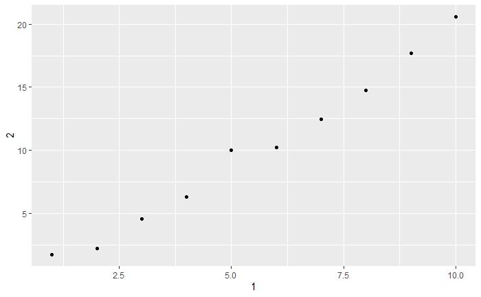

```r
ggplot(data=annoying, mapping=aes(x=`1`, y=`2`)) + geom_point()
```

```r
annoying <- mutate(annoying, `3` = `2` / `1`)
```

```r
annoying <- rename(annoying, one=`1`, two=`1`, three=`3`)
glimpse(annoying)
```

```
Rows: 10
Columns: 3
$ two   <int> 1, 2, 3, 4, 5, 6, 7, 8, 9, 10
$ `2`   <dbl> 1.755118, 2.215839, 4.555301, 6.285756, 10.010140, 10.207783, 12.487619, 14.776260, 17.674016, 2~
$ three <dbl> 1.755118, 1.107919, 1.518434, 1.571439, 2.002028, 1.701297, 1.783946, 1.847033, 1.963780, 2.0575~
```

5. What does `tibble::enframe()` do? When might you use it?

Answer: The function tibble::enframe() converts named vectors to a data frame with names and values

```r
enframe(c(a = 1, b = 2, c = 3))
```

| name | value |
| --- | --- |
| a | 1 |
| b | 2 |
| c | 3 |